# Ford GoBike Membership Insights

### Zainab Mohammed

## Investigation Overview

In this presentation, I will be looking at factors that characterize members of bike_share and relationships between them. I will be focusing on types of users and members who use bike-share for all trips.

## Dataset Overview

After preliminary data wrangling,the dataset contained 174952 observations and 14 Features but after further exploration,the dataset contains 174749 observations and 14 features because I dropped some observations due to inconsistent ages. Four variables(duration_mins, member_age,start_hour and end_hour) are numeric. Date variables are start_date and end_date whiles the rest of the variables are strings

## Distribution of age of members

This is the distribution of ages of members after dropping outliers. The ages are now from 18 years to 78 years. The most occurring ages is between 25 and 35

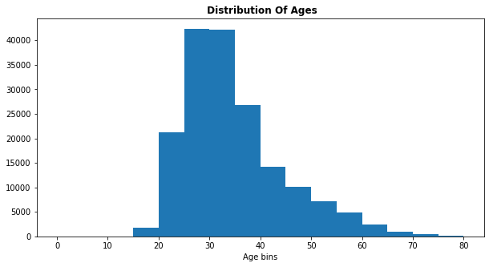

## Distribution of trip duration

This histogram show that most trips last between 5 and 10 minutes

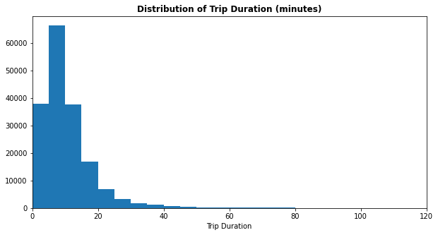

## Proportion of members who are customers or subscribers

This shows the proportion of members who are subscribers and regular customers .  
Subscribers make up approximately 91% of members.

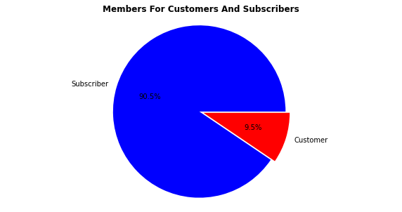

## Bike-share for all their trips

This shows the proportion of members who use bike-share for all their trips  
90.1% of members Do Not use bike_share for all trips.

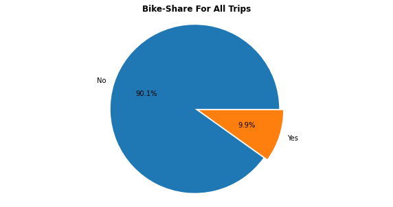

## Distribution of trip based on time of the day

This shows time of the day where members usually use bike-share.  
In this histogram,the distribution of the hour of day is bimodal. Trips usually starts between 8-9am And between 5-6pm.

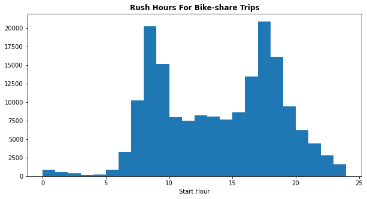

## Number of Members per Gender

Members of this bike share are mostly males.Their numbers are more than twice the Females and even more than 'Other' gender

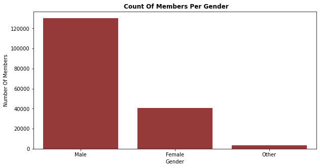

### Number of trips during hours of the day based on user type

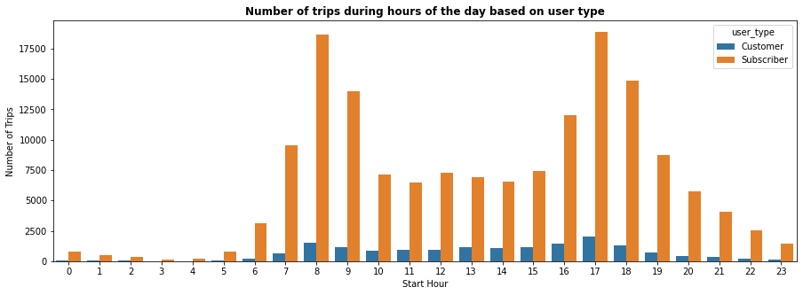

## Trip duration rate during hours of the day for user type

This shows when the average trip duration for user types throughout the day. Both user types go on longer trips during the hours of 3am although customers(non-subscribers) have a significantly higher rate

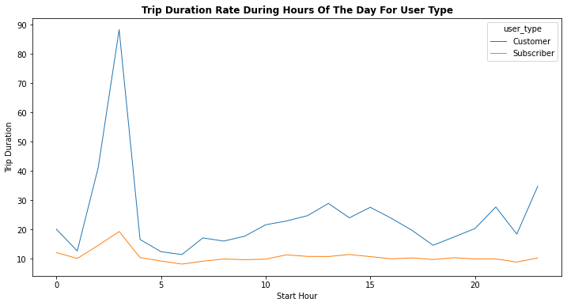

## User type and members who use bike-share for all trips

A big chunk of members who Do Not use bike-share for all their trips are subscribers. Both groups of members do not really use bike-share for all their trips.

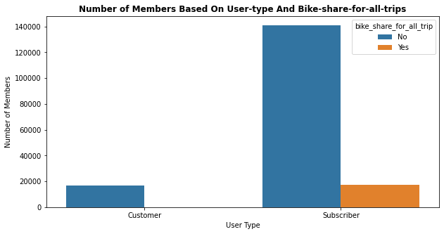

## Average trip duration for user type

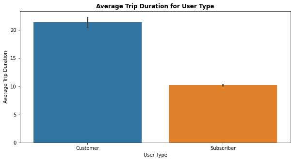

## Trip Duration and User-type

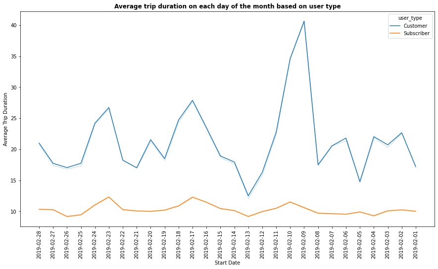

## Trip time covered on each day of the month based on bike_share_for_all_trips

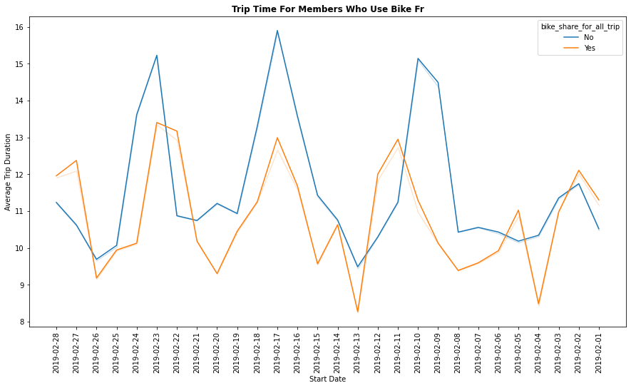